# Data Analysis Project Pt 2

## Animal Outcomes in Austin Animal Shelters Pt. 2

Below data from the Austin Animal Shelter system will be analyzed for correlations between the outcomes of animals and their animal type, age, and sex. This section includes data transformations and graphs.

(there was some weirdness going on when I had to convert my strings which is why it is split into two parts)

```python
import pandas as pd
import numpy as np
import matplotlib.pyplot as plt
import seaborn as sns
import pandas_datareader as pdr
```

```python
animal = pd.read_csv("//Users//audreydahlkemper//Downloads//A1//Austin_Animal_Center_Outcomes.csv")
```

I collected data on Animal Shelters in the Austin Area, 12 intitial variables are represented: Animal ID, Name, DateTime, MonthYear, DOB, Outcome Type, Animal Type, Sex upon Outcome, Age upon Outcome, Breed, and Color.

```python
animal.head()
```

|  | Animal ID | Name | DateTime | MonthYear | Date of Birth | Outcome Type | Outcome Subtype | Animal Type | Sex upon Outcome | Age upon Outcome | Breed | Color |
| --- | --- | --- | --- | --- | --- | --- | --- | --- | --- | --- | --- | --- |
| 0 | A794011 | Chunk | 5/8/19 18:20 | May-19 | 5/2/17 | Rto-Adopt | NaN | Cat | Neutered Male | 2 years | Domestic Shorthair Mix | Brown Tabby/White |
| 1 | A776359 | Gizmo | 7/18/18 16:02 | Jul-18 | 7/12/17 | Adoption | NaN | Dog | Neutered Male | 1 year | Chihuahua Shorthair Mix | White/Brown |
| 2 | A821648 | NaN | 8/16/20 11:38 | Aug-20 | 8/16/19 | Euthanasia | NaN | Other | Unknown | 1 year | Raccoon | Gray |
| 3 | A720371 | Moose | 2/13/16 17:59 | Feb-16 | 10/8/15 | Adoption | NaN | Dog | Neutered Male | 4 months | Anatol Shepherd/Labrador Retriever | Buff |
| 4 | A674754 | NaN | 3/18/14 11:47 | Mar-14 | 3/12/14 | Transfer | Partner | Cat | Intact Male | 6 days | Domestic Shorthair Mix | Orange Tabby |

The first step I took was limiting the extent of the data in order to produce more refined results. Below the number of rows are limited from ~144,000 to 2,000. Each row represents a different animal's outcome. Further down I also limited the amount of columns. Dropping Animal ID, Name, DateTime, DOB, and Color. This reduced the column variables from 12 to 7.

```python
animal = pd.read_csv("//Users//audreydahlkemper//Downloads//A1//Austin_Animal_Center_Outcomes.csv", nrows = 2000)
animal
```

|  | Animal ID | Name | DateTime | MonthYear | Date of Birth | Outcome Type | Outcome Subtype | Animal Type | Sex upon Outcome | Age upon Outcome | Breed | Color |
| --- | --- | --- | --- | --- | --- | --- | --- | --- | --- | --- | --- | --- |
| 0 | A794011 | Chunk | 5/8/19 18:20 | May-19 | 5/2/17 | Rto-Adopt | NaN | Cat | Neutered Male | 2 years | Domestic Shorthair Mix | Brown Tabby/White |
| 1 | A776359 | Gizmo | 7/18/18 16:02 | Jul-18 | 7/12/17 | Adoption | NaN | Dog | Neutered Male | 1 year | Chihuahua Shorthair Mix | White/Brown |
| 2 | A821648 | NaN | 8/16/20 11:38 | Aug-20 | 8/16/19 | Euthanasia | NaN | Other | Unknown | 1 year | Raccoon | Gray |
| 3 | A720371 | Moose | 2/13/16 17:59 | Feb-16 | 10/8/15 | Adoption | NaN | Dog | Neutered Male | 4 months | Anatol Shepherd/Labrador Retriever | Buff |
| 4 | A674754 | NaN | 3/18/14 11:47 | Mar-14 | 3/12/14 | Transfer | Partner | Cat | Intact Male | 6 days | Domestic Shorthair Mix | Orange Tabby |
| ... | ... | ... | ... | ... | ... | ... | ... | ... | ... | ... | ... | ... |
| 1995 | A678179 | Maggie | 6/21/14 18:42 | Jun-14 | 5/5/03 | Return to Owner | NaN | Dog | Spayed Female | 11 years | Chow Chow Mix | Gray |
| 1996 | A859024 | Boshe | 6/13/22 11:21 | Jun-22 | 6/7/16 | Transfer | Partner | Dog | Intact Male | 6 years | Shih Tzu | White/Black |
| 1997 | A845396 | *Zoey | 11/20/21 13:41 | Nov-21 | 9/14/21 | Adoption | NaN | Cat | Spayed Female | 2 months | Domestic Shorthair | Brown Tabby/White |
| 1998 | A801604 | Toby Nugget | 8/6/19 15:36 | Aug-19 | 8/6/13 | Return to Owner | NaN | Dog | Neutered Male | 6 years | Whippet | Tan |
| 1999 | A790975 | *Tiramisu | 3/23/19 19:02 | Mar-19 | 3/19/18 | Adoption | NaN | Dog | Neutered Male | 1 year | Labrador Retriever | Black/Red |

2000 rows × 12 columns

```python
animal.drop(['Animal ID', 'Name', 'DateTime', 'Date of Birth', 'Color'],axis=1,inplace=True)
animal
```

|  | MonthYear | Outcome Type | Outcome Subtype | Animal Type | Sex upon Outcome | Age upon Outcome | Breed |
| --- | --- | --- | --- | --- | --- | --- | --- |
| 0 | May-19 | Rto-Adopt | NaN | Cat | Neutered Male | 2 years | Domestic Shorthair Mix |
| 1 | Jul-18 | Adoption | NaN | Dog | Neutered Male | 1 year | Chihuahua Shorthair Mix |
| 2 | Aug-20 | Euthanasia | NaN | Other | Unknown | 1 year | Raccoon |
| 3 | Feb-16 | Adoption | NaN | Dog | Neutered Male | 4 months | Anatol Shepherd/Labrador Retriever |
| 4 | Mar-14 | Transfer | Partner | Cat | Intact Male | 6 days | Domestic Shorthair Mix |
| ... | ... | ... | ... | ... | ... | ... | ... |
| 1995 | Jun-14 | Return to Owner | NaN | Dog | Spayed Female | 11 years | Chow Chow Mix |
| 1996 | Jun-22 | Transfer | Partner | Dog | Intact Male | 6 years | Shih Tzu |
| 1997 | Nov-21 | Adoption | NaN | Cat | Spayed Female | 2 months | Domestic Shorthair |
| 1998 | Aug-19 | Return to Owner | NaN | Dog | Neutered Male | 6 years | Whippet |
| 1999 | Mar-19 | Adoption | NaN | Dog | Neutered Male | 1 year | Labrador Retriever |

2000 rows × 7 columns

```python
animal.describe()
```

|  | MonthYear | Outcome Type | Outcome Subtype | Animal Type | Sex upon Outcome | Age upon Outcome | Breed |
| --- | --- | --- | --- | --- | --- | --- | --- |
| count | 2000 | 2000 | 923 | 2000 | 2000 | 1999 | 2000 |
| unique | 108 | 7 | 19 | 4 | 5 | 40 | 347 |
| top | Jul-14 | Adoption | Partner | Dog | Neutered Male | 1 year | Domestic Shorthair Mix |
| freq | 34 | 954 | 455 | 1126 | 694 | 352 | 480 |

```python
animal.shape
```

```
(2000, 7)
```

```python
print(type(animal))
```

```
<class 'pandas.core.frame.DataFrame'>
```

All of the variables are classified as an object/string. The later half of this is dedicated to transforming key information into numerical values.

```python
animal.dtypes
```

```
MonthYear           object
Outcome Type        object
Outcome Subtype     object
Animal Type         object
Sex upon Outcome    object
Age upon Outcome    object
Breed               object
dtype: object
```

```python
animal.info()
```

```
<class 'pandas.core.frame.DataFrame'>
RangeIndex: 2000 entries, 0 to 1999
Data columns (total 7 columns):
 #   Column            Non-Null Count  Dtype
---  ------            --------------  -----
 0   MonthYear         2000 non-null   object
 1   Outcome Type      2000 non-null   object
 2   Outcome Subtype   923 non-null    object
 3   Animal Type       2000 non-null   object
 4   Sex upon Outcome  2000 non-null   object
 5   Age upon Outcome  1999 non-null   object
 6   Breed             2000 non-null   object
dtypes: object(7)
memory usage: 109.5+ KB
```

```python
print(animal.columns)
```

```
Index(['MonthYear', 'Outcome Type', 'Outcome Subtype', 'Animal Type',
       'Sex upon Outcome', 'Age upon Outcome', 'Breed'],
      dtype='object')
```

Due to the spacing between the column names I chose to rename the data sets in order to be able to transform the information into int/float values.

```python
animal.rename(columns={'MonthYear':'date', 'Outcome Type':'outcome', 'Outcome Subtype':'outcome_sub', 'Animal Type':'animal_type', 'Sex upon Outcome':'sex', 'Age upon Outcome':'age'}, inplace = True)
animal.head()
```

|  | date | outcome | outcome_sub | animal_type | sex | age | Breed |
| --- | --- | --- | --- | --- | --- | --- | --- |
| 0 | May-19 | Rto-Adopt | NaN | Cat | Neutered Male | 2 years | Domestic Shorthair Mix |
| 1 | Jul-18 | Adoption | NaN | Dog | Neutered Male | 1 year | Chihuahua Shorthair Mix |
| 2 | Aug-20 | Euthanasia | NaN | Other | Unknown | 1 year | Raccoon |
| 3 | Feb-16 | Adoption | NaN | Dog | Neutered Male | 4 months | Anatol Shepherd/Labrador Retriever |
| 4 | Mar-14 | Transfer | Partner | Cat | Intact Male | 6 days | Domestic Shorthair Mix |

### Data Transformation: Outcome, Animal Type, Sex, and Age

```python
animal.outcome.unique()
```

```
array(['Rto-Adopt', 'Adoption', 'Euthanasia', 'Transfer',
       'Return to Owner', 'Died', 'Disposal'], dtype=object)
```

```python
out=animal.outcome.map({'Rto-Adopt': 0, 'Adoption': 1, 'Euthanasia': 2, 'Transfer': 3, 'Return to Owner': 4, 'Died': 5, 'Disposal': 6})
out.head()
```

```
0    0
1    1
2    2
3    1
4    3
Name: outcome, dtype: int64
```

```python
animal.animal_type.unique()
```

```
array(['Cat', 'Dog', 'Other', 'Bird'], dtype=object)
```

```python
typ=animal.animal_type.map({'Other':0, 'Dog':1, 'Cat':2, 'Bird':3 })
typ.head()
```

```
0    2
1    1
2    0
3    1
4    2
Name: animal_type, dtype: int64
```

```python
animal.sex.unique()
```

```
array(['Neutered Male', 'Unknown', 'Intact Male', 'Spayed Female',
       'Intact Female'], dtype=object)
```

```python
sx=animal.sex.map({'Unknown': 0, 'Neutered Male': 1, 'Intact Male': 2, 'Spayed Female': 3, 'Intact Female': 4})
sx.head()
```

```
0    1
1    1
2    0
3    1
4    2
Name: sex, dtype: int64
```

```python
animal.age.unique()
```

```
array(['2 years', '1 year', '4 months', '6 days', '7 years', '2 months',
       '2 days', '3 weeks', '11 years', '9 months', '4 weeks', '2 weeks',
       '6 months', '3 months', '9 years', '10 years', '8 years',
       '3 years', '7 months', '6 years', '4 years', '1 month', '12 years',
       '5 years', '1 weeks', '5 months', '5 days', '15 years',
       '11 months', '10 months', '4 days', '16 years', '1 day',
       '8 months', '13 years', '1 week', '14 years', nan, '3 days',
       '0 years', '5 weeks'], dtype=object)
```

```python
ag=animal.age.map({'0 years':0, '1 day': 1, '2 days':2, '3 days':3, '4 days':4, '5 days':5, '6 days': 6, '1 weeks': 7, '2 weeks': 8, '3 weeks': 9, '4 weeks': 10, '5 weeks': 11, '1 month': 12, '2 months': 13, '3 months': 14, '4 months': 15, '5 months': 16, '6 months': 17, '7 months': 18, '8 months': 19, '9 months': 20, '10 months': 21, '11 months': 22, '1 year': 23, '2 years': 24, '3 years': 25, '4 years': 26, '5 years': 27, '6 years': 28, '7 years': 29, '8 years': 30, '9 years': 31, '10 years': 32, '11 years': 33, '12 years': 34, '13 years': 35})
ag.head()
```

```
0    24.0
1    23.0
2    23.0
3    15.0
4     6.0
Name: age, dtype: float64
```

Below I created a new data frame that included only the numerical values in order to create more accurate graphs.

```python
animal2= pd.concat([out, typ, ag, sx], axis=1)
animal2.head()
```

|  | outcome | animal_type | age | sex |
| --- | --- | --- | --- | --- |
| 0 | 0 | 2 | 24.0 | 1 |
| 1 | 1 | 1 | 23.0 | 1 |
| 2 | 2 | 0 | 23.0 | 0 |
| 3 | 1 | 1 | 15.0 | 1 |
| 4 | 3 | 2 | 6.0 | 2 |

```python
animal2.dtypes
```

```
outcome          int64
animal_type      int64
age            float64
sex              int64
dtype: object
```

## Graphs

### Countplots

Animal Sex Key: 0=Unknown, 1=Neutered Male, 2=Intact Male, 3=Spayed Female, 4=Intact Female

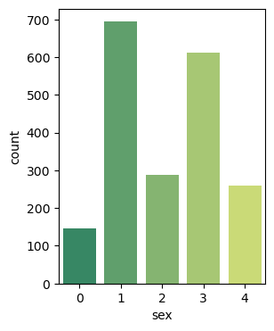

```python
sns.countplot(data=animal2, x='sex', palette='summer')
```

A high rate of neutered Male and spayed Female animals.

Animal Type Key: 0=Other, 1=Dog, 2=Cat, 3=Bird

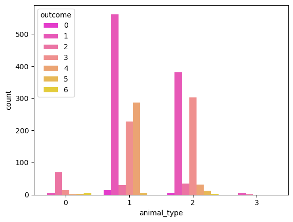

```python
sns.countplot(data=animal2, x='animal_type', hue='outcome', palette='spring');
```

Confirms findings from pt.1, dogs have the highest adoption rates and cats have the highest transfer rates.

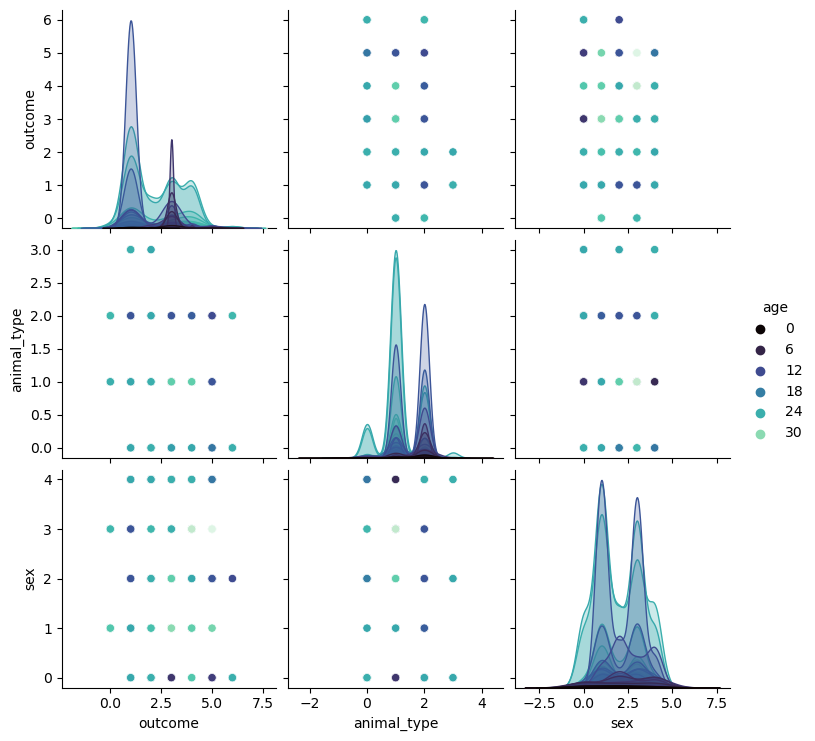

```python
sns.pairplot(data=animal2, hue='age', palette='mako')
```

Not too much a correlation between a lot of the variables. Specifically age, type, and sex. This graph could be strengthened if used in the future.

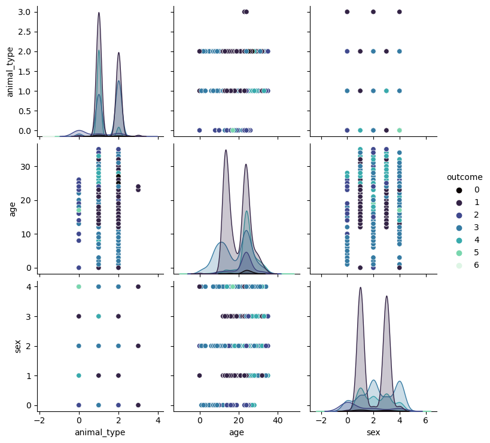

```python
sns.pairplot(data=animal2, hue='outcome', palette='mako')
plt.figure(figsize=(10,12))
```

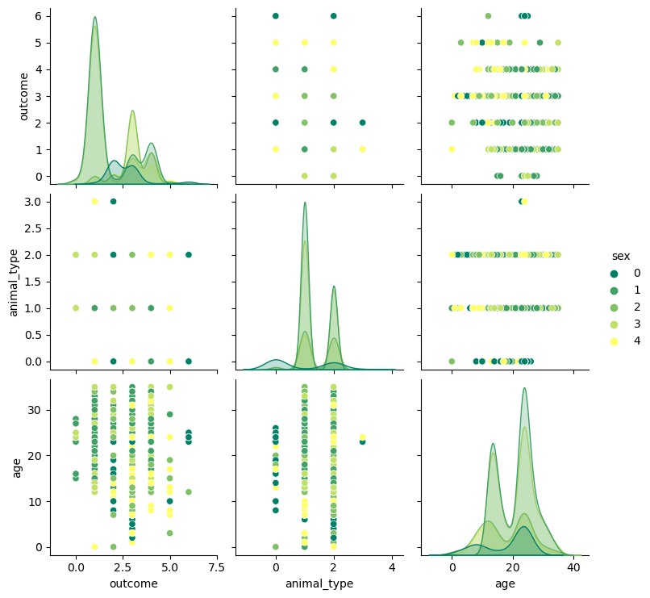

```python
sns.pairplot(data=animal2, hue='sex', palette='summer')
```

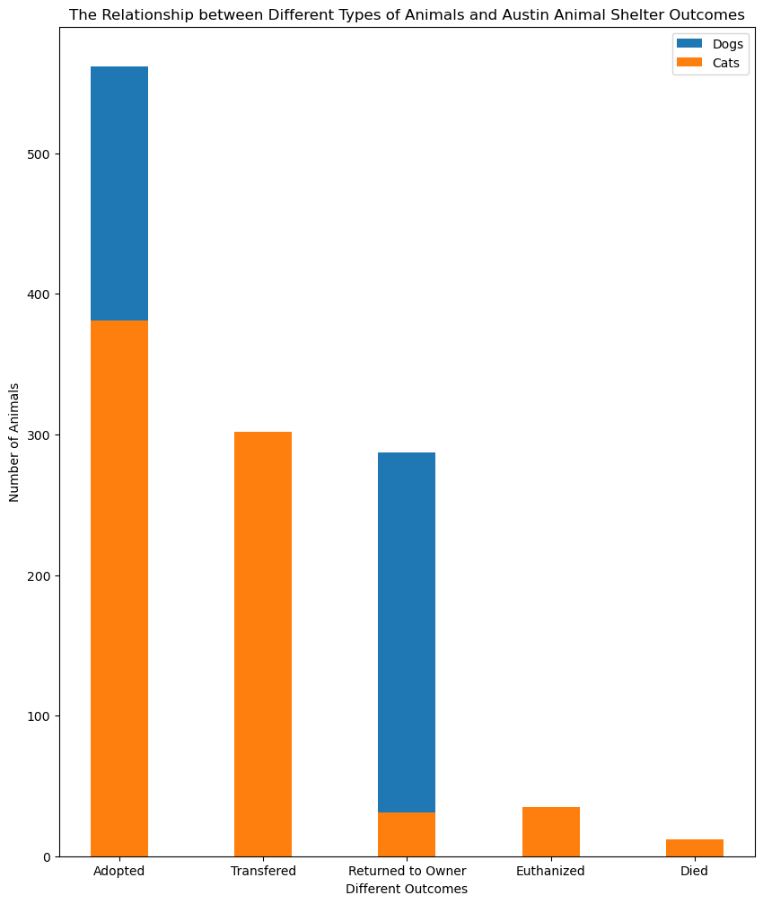

```python
w=0.4
x= ['Adopted', 'Transfered', 'Returned to Owner', 'Euthanized', 'Died']
Dogs = [562, 228, 287, 30, 6]
Cats = [381, 302, 31, 35, 12]
plt.figure(figsize=(10,12))

plt.bar(x,Dogs,w,label='Dogs')
plt.bar(x,Cats,w,label='Cats')

plt.xlabel("Different Outcomes")
plt.ylabel("Number of Animals")
plt.title("The Relationship between Different Types of Animals and Austin Animal Shelter Outcomes")


plt.legend()
plt.show()
```

Adoption, transfer, return, euthanization, and death between cats vs dogs. Dogs maintain the highest adoption rate and the highest return to owner rate.